# Bayesian Structural Time Seires

Time Series

Bayesian Structural Time Seires for Time Series Data

Yeongeun Jeon , Jung In Seo  
06-30-2021

- Data 출처 : [Data Mining for Business Analytics](https://www.dataminingbook.com/book/r-edition)에서 사용한 미국 철도 회사 “Amtrak”에서 수집한 1991년 1월~2004년 3월까지 매달 환승 고객 수

# **Introduction**

- Bayesian Structural Time Series (BSTS)는 `Structural Time Seires (STS) 모형에 Bayesian 방법을 적용`하는 방법이다.
- STS는 Linear Gaussian State Space Model로써 `Dynamic Linear Model (DLM)과 동일한 개념`이다.
- STS의 장점은 다음과 같다.
  - 유연성(Flexible) : 모든 ARIMA 및 VARMA 모델을 포함하여 매우 큰 클래스의 모델을 상태 공간 형식으로 표현할 수 있다.
  - 모듈식(Modular) : 데이터의 중요한 특징을 포착하기 위해 모형은 상태 성분(State-component) 하위 모델(Sub-model)의 라이브러리로부터 조립될 수 있다.
    - 추세(Trend), 계절성(Seasonality) 등을 포착하기 위해 널리 사용되는 여러 상태 성분을 사용할 수 있다.
- $t$시점에서 관측된 시계열 데이터 $y_{t}$가 $m$차원이고, 관측되지 않는(Unobserved) 상태 성분이 $p$차원일 때, STS는 방정식은 다음과 같다.

$$\begin{aligned}
Y_{t}&=Z^{T}_{t}\alpha_{t}+\epsilon_{t},~~~~~~~\epsilon_{t}\sim N_{m}(0,H_{t}), \\
\alpha_{t+1}&=T_{t}\alpha_{t}+R_{t}\eta_{t},~~~\eta_{t}\sim N_{q}(0,Q_{t}),\\
\alpha_{1} &\sim N_{p} (\mu_{1}, P_{1})
\end{aligned}$$

- 첫번째는 관측방정식, 두번째는 상태방정식이다.
  - $Y_{t}$ : 시점 $t$에서 관측값
  - $\alpha_{t}$ : 시점 $t$에서 관측할 수 없는 상태 (시계열에서 추세, 계절성 등이 상태가 될 수 있음)
    - 직접 관찰할 수 없지만 시간이 지남에 따라 어떻게 변화하는지 알고 있다고 가정하는 것이 합리적
    - 시간이 지남에 따라 어떻게 변화하는지 정의
  - $Z_{t}$, $T_{t}$, $R_{t}$ : 0과 1을 포함하여 알고 있는 값과 미지의 모수를 포함하는 행렬
    - $Z_{t}$ : $p\times m$ 결과 행렬 (Output Matirx)
    - $T_{t}$ : $p\times p$ 전이 행렬 (Transition Matrix)
    - $R_{t}$ : $p\times q$ 제어 행렬 (Control Matrix)
  - $\epsilon_{t}$, $\eta_{t}$ : 오차로써, 연속적으로 상관관계가 없으며 또한 모든 기간 동안 서로 상관관계가 없는 것으로 가정한다.
    - $\epsilon_{t}$ : $m\times m$ 분산공분산행렬(Variance-covariance Matrix) $H_{t}$을 가진 $m\times 1$ 벡터
    - $\eta_{t}$ : $q\times q$ 상태확산행렬(State Diffusion Matrix) $Q_{t}$을 가진 $q \times 1$ 벡터 ($q\le d$)

# **BSTS Package**

- BSTS는 R package `bsts`를 통해 다룰 수 있다.
  - `bsts`는 Markov chain Monte Carlo (MCMC) 방법으로 BSTS의 사후분포로부터 표본을 추출하여 적합과 예측이 수행된다.
- 다음으로, 관측값 $y_{t}$가 univariate time series일 때 BSTS에서 가장 유용하게 쓰이는 대표적인 모형들에 대해 설명한다. 다른 모형들에 대해서는 [여기](http://oliviayu.github.io/post/2019-03-21-bsts/)를 참조한다.

## **Trend**

### **Local Level Model**

- 관측값 $y_{t}$를 추세의 평균인 Level $\mu_{t}$로만 나타낸 간단한 모형식이다.
  - Random Walk + 오차
- $Z^{T}_{t} = 1$, $T_{t} = 1$, $\alpha_{t}=\mu_{t}$, $R_{t} = 1$, $\eta_{t} = \xi_{t}$일 때, 모형식은 다음과 같다.

$$\begin{aligned}
Y_{t} &= \mu_{t} + \epsilon_{t},~~~~\epsilon_{t}\sim N(0, \sigma^2_{\epsilon})\\
\mu_{t+1} &= \mu_{t} + \xi_{t}, ~~~\xi_{t}\sim N(0,\sigma^2_{\xi }),
\end{aligned}$$

- R package `"bsts"`에서 `AddLocalLevel()`을 사용하면 된다.

```
ss <- list()
ss <- bsts::AddLocalLevel(ss, y)   # y : The time series to be modeled
```

### **Local Linear Trend Model**

- 관측값 $y_{t}$를 추세의 평균인 Level $\mu_{t}$와 추세의 기울기(=추세의 증가률) $\delta_{t}$로 나타낸 모형식이다.
- Linear Trend Model보다 유연하며, 단기 예측에 유용하다.
- $Z^{T}_{t} = (1, 0)$, $T_{t} = \left[\begin{matrix} 1 & 1\\ 0 & 1 \end{matrix}\right]$, $\alpha_{t}=(\mu_{t}, \delta_{t})^{T}$, $R_t=\left[\begin{matrix} 1 & 0 \\ 0 & 1 \end{matrix}\right]$, $\eta_{t}=(\xi_{t},\zeta_{t})^{T}$일 때, 모형식은 다음과 같다.

$$\begin{aligned}
Y_{t} &= \mu_{t} + \epsilon_{t},~~~~~~~~~~\epsilon_{t}\sim N(0, \sigma^2_{\epsilon})\\
\mu_{t+1} &= \mu_{t} + \delta_{t} + \xi_{t}, ~~~\xi_{t}\sim N(0,\sigma^2_{\xi }),\\
\delta_{t+1} &= \delta_{t} + \zeta_{t}, ~~~~~~~~~~~~\zeta_{t}\sim N(0,\sigma^2_{\zeta}),
\end{aligned}$$

- R package `"bsts"`에서 `AddLocalLinearTrend()`을 사용하면 된다.

```
ss <- list()
ss <- bsts::AddLocalLinearTrend(ss, y)   # y : The time series to be modeled
```

## **Seasonality**

### **Regression with Seasonal Dummy Variables**

- 계절성을 포착하기 위해 흔히 사용되는 상태 성분 모형이다.
  - 서로 다른 주기를 가진 다중 계절 성분을 허용하는 모형으로 확장할 수 있다.
- 관측값 $y_{t}$의 계절 주기가 $S$, $Z^{T}_{t} = (1, 0,\ldots, 0)$, $T_{t} = \left[\begin{matrix} -1 & - 1 & \cdots & -1 & -1 \\ 1 & 0 & \cdots & 0 & 0\\ 0 & 1 & \cdots & 0 & 0 \\ \vdots &\vdots &\vdots & \vdots &\vdots \\ 0 & 0 & \cdots & 1 & 0 \end{matrix}\right]$, $\alpha_{t}=(\tau_{t}, \ldots, \tau_{t-S+2})^{T}$, $R_{t}=(1,0,\ldots,0)^{T}$, $\eta_{t}=\omega_{t}$일 때, 모형식은 다음과 같다.

$$\begin{aligned}
Y_{t} &= \tau_{t} + \epsilon_{t},~~~~~~~~~~\epsilon_{t}\sim N(0, \sigma^2_{\epsilon})\\
\tau_{t+1} &= -\sum_{s=1}^{S-1} \tau_{t+1-s} + \omega_{t}, ~~~\omega_{t}\sim N(0,\sigma^2_{\omega}),
\end{aligned}$$

- R package `"bsts"`에서 `AddSeasonal()`을 사용하면 된다.

```
ss <- list()
ss <- bsts::AddSeasonal(ss, y,           # y : The time series to be modeled
                        nseasons,        # season.duration의 반복 수
                        season.duration) # 각 시즌에서 관측수수

# cycle (s) = season.duration * nseasons
```

# **Application**

- Ridership on Amtrak Trains(미국 철도 회사 “Amtrak”에서 수집한 1991년 1월~2004년 3월까지 매달 환승 고객 수) 예제를 이용하여 BSTS가 실제 데이터에 어떻게 적용되는지 설명한다.

## **Data 불러오기**

```
pacman::p_load("dplyr", "bsts", "forecast", "ggplot2")

# In Mac
# guess_encoding("Amtrak.csv")
# Amtrak.data <- read.csv("Amtrak.csv", fileEncoding="EUC-KR")

Amtrak.data  <- read.csv("C:/Users/User/Desktop/Amtrak.csv")
ridership.ts <- ts(Amtrak.data$Ridership, start=c(1991,1), end=c(2004,3), freq=12)
```

## **Data 분할**

```
train.ts  <- window(ridership.ts,start=c(1991,1), end=c(2001,3))   # Training Data
test.ts   <- window(ridership.ts,start=c(2001,4))                  # Test Data
n.test    <- length(test.ts)
```

## **정규성 확인**

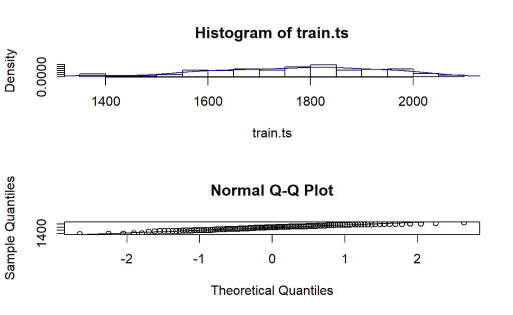

```
par(mfrow=c(2,1))
hist(train.ts, prob=TRUE, 12)
lines(density(train.ts), col="blue")
qqnorm(train.ts)
qqline(train.ts)
```

- 두 그래프를 보면 Ridership은 정규분포를 따른다는 것을 알 수 있다.

## **모형 적합**

- `bsts` package에 있는 `bsts()`을 이용하여 모형을 적합시킬 수 있다.

```
bsts(formula, state.specification, family = c("gaussian", "logit", "poisson", "student"), data, niter, seed = NULL, ...)
```

- formula : 시계열 데이터 $y_{t}$와 예측변수 $x_{i,t}$ 사이의 관계를 설명하는 형태
  - 예측변수가 존재하지 않을 때 : y
  - 예측변수가 존재할 때 : $y\sim x$
- state.specification : BSTS Package에서 소개된 상태 성분에 대한 모형식
- family : 관측방정식의 분포
- data : formula에서 나타낸 변수를 포함하는 Data Frame 형태의 변수
- niter : 추출하기 원하는 MCMC 수
- seed : 실행시킬 때마다 다른 결과가 나오지 않게 고정할 시드 값
- 예제 데이터에서는 대중적이고 유용한 `Basic STS Model`을 이용하여 적합하고자 한다.
- 회귀 성분(=예측 변수)를 포함하는 `Basic STS Model`은 다음과 같다.

$$\begin{aligned}
Y_{t} &= \mu_{t} + \tau_{t} + \beta^{T}x_{t} + \epsilon_{t},~~~~\epsilon_{t}\sim N(0, \sigma^2_{\epsilon})\\
\mu_{t+1} &= \mu_{t} + \delta_{t} + \xi_{t}, ~~~~~~~~~\xi_{t}\sim N(0,\sigma^2_{\xi }),\\
\delta_{t+1} &= \delta_{t} + \zeta_{t}, ~~~~~~~~~~~~~~~~~~~~~\zeta_{t}\sim N(0,\sigma^2_{\zeta})\\
\tau_{t+1}&=-\sum_{s=1}^{S-1} \tau_{t+1-s} + \omega_{t}, ~~~~~~~~~~\omega_{t}\sim N(0,\sigma^2_{\omega })
\end{aligned}$$
- Basic STS Model은 $Z^{T}_{t} = (1,0,1,\ldots, 0)$, $T_{t} = \left[\begin{smallmatrix} 1 & 1 & \\ 0 & 1 & \\ & & -1 & - 1 & \cdots & -1 & -1 \\ & & 1 & 0 & \cdots &0& 0\\ & & 0 & 1 & \cdots & 0 &0 \\ & & \vdots &\vdots &\vdots &\vdots &\vdots &\\ & & 0 & 0 & \cdots & 1 & 0 \end{smallmatrix}\right]$, $\alpha_{t} = (\mu_{t}, \delta_{t}, \tau_{t}, \ldots, \tau_{t-S+2})^{T}$, $R_{t}=\left[\begin{smallmatrix}1 & 0 \\ 0 & 1 \\ & & 1 \\ & & 0 \\ & & \vdots \\ & & 0 \\ \end{smallmatrix}\right]$, $\eta_{t}=(\xi_{t}, \zeta_{t},\omega_{t})^{T}$.

```
# Local Linear Trend
ss <- list()
ss <- bsts::AddLocalLinearTrend(ss, train.ts)
# Seasonal
ss <- bsts::AddSeasonal(ss, train.ts, nseasons = 12, season.duration = 1)

BSTS.fit <- bsts(train.ts, state.specification = ss, niter = 1000, seed=100)  # niter : MCMC 반복복
```

[output not shown]

```
summary(BSTS.fit)
```

```
$residual.sd
[1] 38.96105

$prediction.sd
[1] 86.43389

$rsquare
[1] 0.9407548

$relative.gof
[1] 0.7354909
```

## **예측**

```
burn          <- SuggestBurn(0.1, BSTS.fit)     # MCMC에서 버릴 갯수릴 갯수
BSTS.forecast <- predict(BSTS.fit, horizon = n.test, burn = burn,  quantiles = c(0.025, 0.975))  # horizon : the number of prediction
BSTS.forecast$mean
```

```
 [1] 2008.007 2034.247 2005.145 2114.927 2159.952 1849.643 1985.271
 [8] 1980.410 2025.083 1771.644 1738.847 2042.618 2047.263 2078.716
[15] 2049.774 2156.080 2205.664 1890.307 2028.975 2029.909 2066.173
[22] 1817.965 1788.446 2091.587 2098.778 2123.918 2100.609 2209.087
[29] 2258.041 1946.782 2080.985 2076.564 2118.590 1871.648 1843.989
[36] 2146.205
```

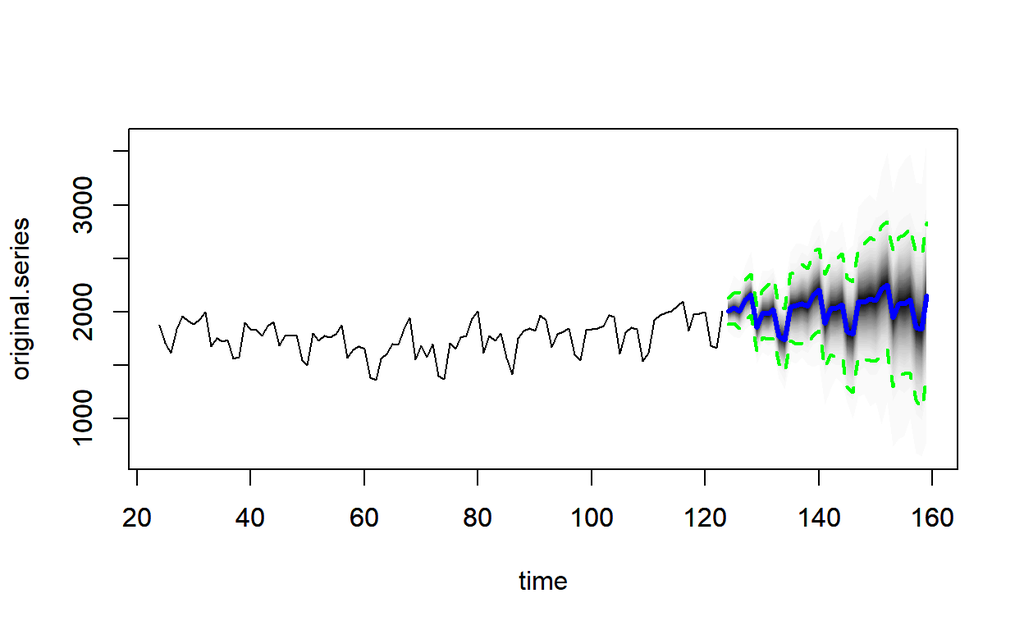

```
plot(BSTS.forecast, plot.original = 100)
```

```
accuracy(test.ts, BSTS.forecast$mean)
```

```
               ME     RMSE      MAE      MPE     MAPE
Test set 30.17445 66.89158 46.26838 1.502453 2.293063
```

## **모형 적합 with 예측 변수**

```
## Month 변수 생성생성
xts(ridership.ts, order = as.Date(ridership.ts))
```

[output not shown]

[output cut: 105 more lines]

[output not shown]

[output not shown]

[output not shown]

```
summary(BSTS.fit2)
```

```
$residual.sd
[1] 38.38387

$prediction.sd
[1] 86.37815

$rsquare
[1] 0.9424972

$relative.gof
[1] 0.7358398

$size
   Min. 1st Qu.  Median    Mean 3rd Qu.    Max.
0.00000 0.00000 0.00000 0.07092 0.00000 1.00000

$coefficients
                 mean       sd mean.inc   sd.inc   inc.prob
Month       0.1077952 0.539501 1.519912 1.414357 0.07092199
(Intercept) 0.0000000 0.000000 0.000000 0.000000 0.00000000
```

### **회귀 계수**

[output not shown]

```
               value    Variable
(Intercept) 0.000000 (Intercept)
Month       1.519912       Month
```

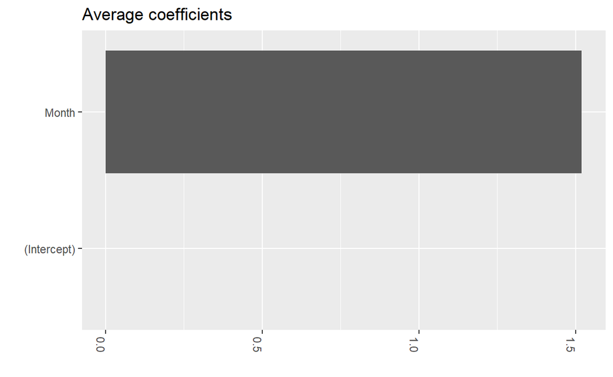

```
ggplot(data=coeff, aes(x=reorder(Variable,value), y=value)) +
  coord_flip()+
  geom_bar(stat="identity", position="identity") +
  theme(axis.text.x=element_text(angle = -90, hjust = 0)) +
  xlab("") + ylab("") + ggtitle("Average coefficients")
```

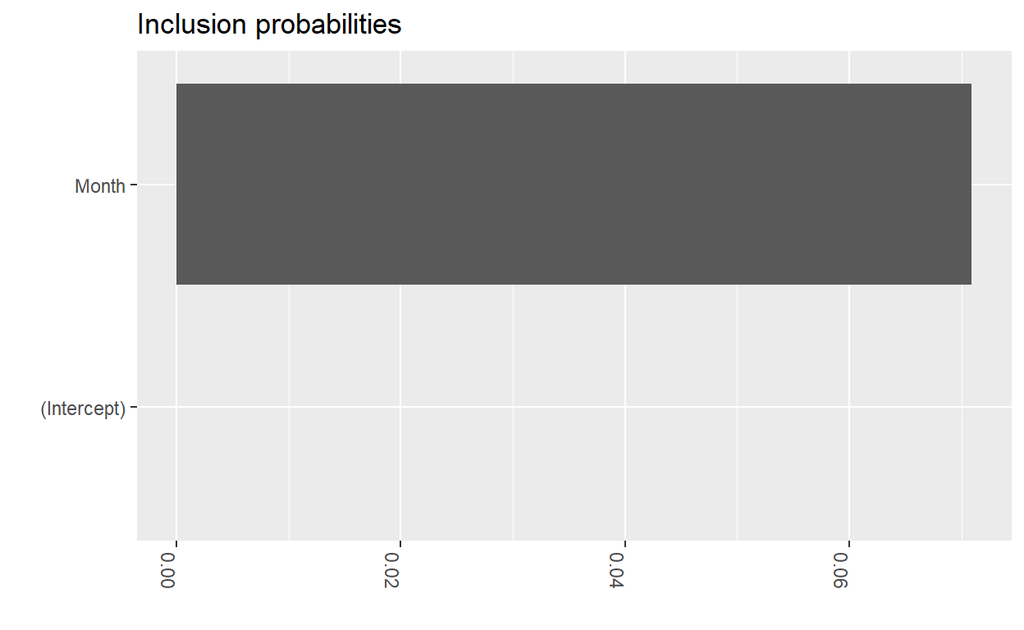

```
### Inclusion probabilities -- i.e., how often were the variables selected
inclusionprobs <- reshape2::melt(colMeans(BSTS.fit2$coefficients[-(1:burn2),] != 0))
inclusionprobs$Variable <- as.character(row.names(inclusionprobs))
ggplot(data=inclusionprobs, aes(x=reorder(Variable, value), y=value)) +
  geom_bar(stat="identity", position="identity") +
  theme(axis.text.x=element_text(angle = -90, hjust = 0)) +
  coord_flip()+
  xlab("") + ylab("") + ggtitle("Inclusion probabilities")
```

### **예측 with 예측 변수**

```
# 예측
BSTS.forecast2 <- predict(BSTS.fit2, horizon = n.test, burn = burn2, newdata = Month[-(1:length(train.ts))], # newdata : 예측변수를 포함하는 변수
                          quantiles = c(0.025, 0.975))  # horizon : the number of prediction
BSTS.forecast2$mean
```

```
 [1] 2008.649 2033.859 2005.471 2115.656 2159.608 1849.589 1985.606
 [8] 1980.895 2025.518 1771.432 1738.900 2042.580 2046.658 2077.231
[15] 2049.163 2155.931 2204.486 1889.507 2028.428 2029.719 2066.013
[22] 1816.823 1787.502 2091.551 2097.854 2122.777 2100.560 2208.762
[29] 2256.867 1945.645 2080.120 2076.238 2118.645 1870.599 1843.099
[36] 2145.638
```

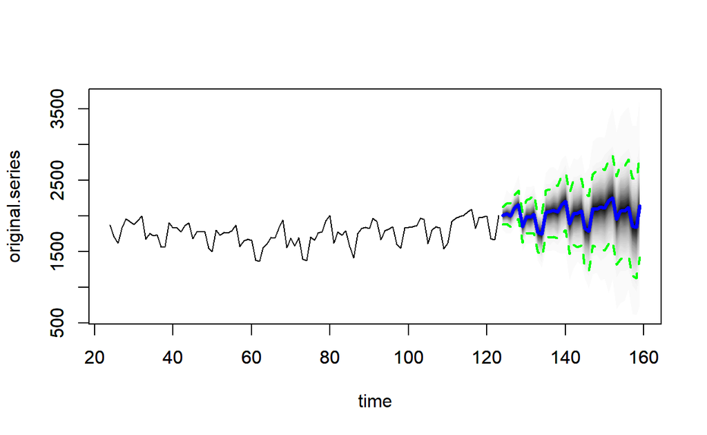

```
plot(BSTS.forecast2, plot.original = 100)
```

```
accuracy(BSTS.forecast2$mean, test.ts)
```

```
                ME     RMSE      MAE       MPE     MAPE      ACF1
Test set -29.77804 66.58763 45.96603 -1.599523 2.379736 0.5265906
         Theil's U
Test set 0.3875899
```